# IODS course project

# Chapter 1: Tools and methods for open and reproducible research

## Introduction to Open Data Science

Introduction to Open Data Science is a course for (doctoral) students who wish to learn more about:  
1. open data  
2. open science  
3. data science

## My github repository

[Link](https://github.com/osilvenn/IODS-project)

# Chapter 2: Linear regression and model validation

This is a report that describes my work on the second week’s RStudio exercise in the course Introduction to Open Data Science. The dataset concerns the relationship between learning results and various factors related to learning styles in an introductory statistics class.

## Part 1

I began by downloading the dataset from the file on my computer. I specified that commas were used as separators and that there was a header row in the file.  
`learning2014 <- read.table("/Users/ollisilvennoinen/IODS-project/chapter2.Rmd", sep = ",", header = TRUE)`  
I then explored the structure and dimensions of the file using the code below.  
`str(learning2014)`  
`dim(learning2014)`  
Starting with the dimensions, the dataset is a 166x7 data frame, i.e. there are 166 observations and seven variables. Here is the output of the `str` function:  
‘data.frame’: 166 obs. of 7 variables:  
$ age : int 53 55 49 53 49 38 50 37 37 42 …  
$ attitude: num 3.7 3.1 2.5 3.5 3.7 3.8 3.5 2.9 3.8 2.1 …  
$ points : int 25 12 24 10 22 21 21 31 24 26 …  
$ gender : Factor w/ 2 levels “F”,“M”: 1 2 1 2 2 1 2 1 2 1 …  
$ deep : num 3.75 2.88 3.88 3.5 3.75 …  
$ surf : num 2.58 3.17 2.25 2.25 2.83 …  
$ stra : num 3.38 2.75 3.62 3.12 3.62 …

As I stated above, the research question was what factors explain learning outcomes. Learning outcomes are measured by the variable `points`; this is the target variable. All the other variables are potential explanatory variables. Here are brief descriptions of the variables:  
* `age`: age of the subjects  
* `attitude`: attitude towards statistics, on a scale from 1 to 5  
* `points`: points received on an exam  
* `gender`: gender of the subjects (male or female)  
* `deep`: mean score on questions related to deep learning  
* `surf`: mean score on questions related to surface learning  
* `stra`: mean score on questions related to strategic learning  
More information on the dataset can be found on [Kimmo Vehkalahti’s webpage](http://www.helsinki.fi/~kvehkala/JYTmooc/JYTOPKYS3-meta.txt).

## Part 2

After this preliminary look into the structure of the dataset, we may now move on to specifics. I explored the variables graphically using the function `ggpairs`:  
`install.packages("ggplot2")`  
`library(ggplot2)` `install.packages("GGally")` `library(GGally)` `p <- ggpairs(learning2014, mapping = aes(col = gender), lower = list(combo = wrap("facethist", bins = 20)))` `p` This yielded the following figure:

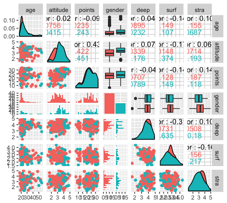

Men are indicated as turquoise, women as red. Based on the figure, genders do seem to pattern somewhat differently, though there do not appear to be any categorical distinctions, which is as expected. For the most part, the correlation coefficients, which can be seen on the upper-right side of the figure, are similar across genders. Exceptions include the interaction of deep and strategic learning as well as deep learning and attitude.  
When we zoom in to `points`, which will be our variable of interest in what follows, the most notable correlation coefficients are those of `attitude` (0.437), `surf` (-0.144) and `stra` (0.146). When it comes to `age`, it is interesting to note that the two genders pattern differently.

## Parts 3 and 4

Now that the structure of the dataset and the variables has been described, we can turn to the regression modelling. I decided to see the effects of the variables `gender`, `attitude` and `stra`. This allows me to explore both sociological and social-psychological factors in one model.  
The following code was used to create the model:  
`model1 <- lm(points ~ gender + attitude + stra, data = learning2014)`  
The summary statistics of `model1` were accessed using the `summary` function:  
`summary(model1)`  
Here is the output:  
Call:  
lm(formula = points ~ gender + attitude + stra, data = learning2014)

Residuals:  
Min 1Q Median 3Q Max  
-17.7179 -3.3285 0.5343 3.7412 10.9007

Coefficients:  
Estimate Std. Error t value Pr(>|t|)  
(Intercept) 8.9798 2.4030 3.737 0.000258 ***  
genderM -0.2236 0.9248 -0.242 0.809231  
attitude 3.5100 0.5956 5.893 2.13e-08 ***  
stra 0.8911 0.5441 1.638 0.103419

Residual standard error: 5.304 on 162 degrees of freedom  
Multiple R-squared: 0.2051, Adjusted R-squared: 0.1904  
F-statistic: 13.93 on 3 and 162 DF, p-value: 3.982e-08

The multiple R<sup>2</sup> indicates that 20.5% of the exam score is explained by the model. Disappointingly, only `attitude` has a significant contribution to the value of `points`, meaning that the 20.5% is solely due to attitudinal factors. Therefore, I ran the regression again using only `attitude` as an explanatory variable.  
`model2 <- lm(points ~ attitude, data = learning2014)`  
`model2`  
The output is short and sweet:  
Call: lm(formula = points ~ attitude, data = learning2014)

Coefficients: (Intercept) attitude  
11.637 3.525

The result is, then, that a positive attitude correlates with exam success, while gender and a strategic learning style do not.

## Part 5

To finalise the analysis, I produced diagnostic figures on the model. The code was as follows:  
`par(mfrow = c(2,2))`  
`plot(model2, which = c(1, 2, 5))`  
Here are the plots:

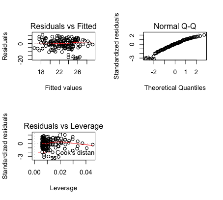

The first figure shows *residuals versus fitted values*. There is not much patterning here, which suggests that the assumptions of linear regression are not violated, at least not strongly. The second figure shows *the QQ plot*, in which the observations fall on the regression line, again suggesting that the assumptions are met reasonably well. The third plot measures *residuals versus leverage*. Since the leverage scores shown on the plot are small, no individual observations seem to have excessive leverage in comparison with the others, so the assumptions of linear regression modelling are met yet again.

# Chapter 3: Logistic regression

This document is a report on RStudio exercise 3 on the IODS course. The goal is to study factors having an effect on alcohol consumption. The source of the dataset is the UCI Machine Learning Library; [here](https://archive.ics.uci.edu/ml/datasets/STUDENT+ALCOHOL+CONSUMPTION) is a link to where the dataset can be downloaded.

## Getting started

Let us start by downloading the dataset from the `data` folder.

```r
alc <- read.table("/Users/ollisilvennoinen/IODS-project/data/alc.csv", sep = ",", header = TRUE)
```

We then continue by looking at the columns in the data file:

```r
colnames(alc)
```

```
##  [1] "X"          "school"     "sex"        "age"        "address"
##  [6] "famsize"    "Pstatus"    "Medu"       "Fedu"       "Mjob"
## [11] "Fjob"       "reason"     "nursery"    "internet"   "guardian"
## [16] "traveltime" "studytime"  "failures"   "schoolsup"  "famsup"
## [21] "paid"       "activities" "higher"     "romantic"   "famrel"
## [26] "freetime"   "goout"      "Dalc"       "Walc"       "health"
## [31] "absences"   "G1"         "G2"         "G3"         "alc_use"
## [36] "high_use"
```

The dataset contains a number of background variables as well as the variable that we are interested in studying, i.e., `high_use`, whether a given participant has high alcohol use or not. The page that contains the data files (linked above) also provides information on the variables. There are 35 variables and 382 observations (in addition, there is a column that gives a unique identifying integer for each observation).

In this assignment, I shall examine the effects of the following variables on high alcohol use:  
* `sex`: my hypothesis is that males use alcohol more than females  
* `age` (ranging from 15 to 22): my hypothesis is that the older the student, the more likely they are to display high use of alcohol  
* `Medu` (ranging from 0 to 4 on an ordinal scale, 0 being low and 4 high education): my hypothesis is that when a child’s mother has low educational attainment, the child is more likely to use alcohol; this is based on the assumption that the mother’s educational attainment is a reliable indicator of the social status of the family (so I do not assume a causal relationship from the mother’s education to their child’s alcohol use)  
* `G3` (average of final period grade in math and Portuguese, ranging from 0 to 20): my hypothesis is that the lower the grade, the higher the likelihood of high alcohol use

## Initial explorations of the variables

Let us begin by considering each variable in isolation, starting with sex. Here is the breakdown of high users of alcohol by gender (note that TRUE means that the informant is a high user of alcohol). As the cross-tabulation shows, men seem to be more likely to be high users.

```r
table(alc$high_use, alc$sex)
```

```
##
##           F   M
##   FALSE 156 112
##   TRUE   42  72
```

Next up is the age of the informants, which I visualise using a boxplot; for this, I need the `ggplot2` package.

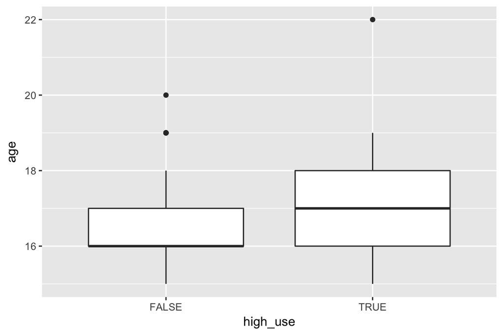

```r
library(ggplot2)
g1 <- ggplot(alc, aes(x = high_use, y = age))
g1 + geom_boxplot() + ylab("age")
```

As the boxplot shows, those who are coded as being high users are older on average, as my original hypothesis predicted.

Third, I look at `Medu`, this time using a mosaic plot.

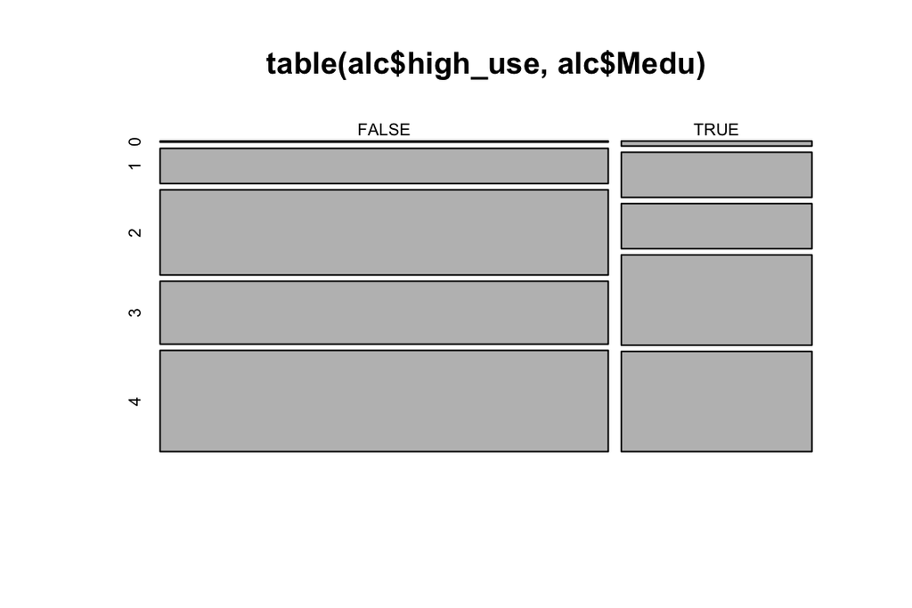

```r
plot(table(alc$high_use, alc$Medu))
```

The verdict for my hypothesis is mixed: getting 1 is more common for the high user group, but so is getting 3.

Finally, I shall have a look at final grades and high alcohol use.

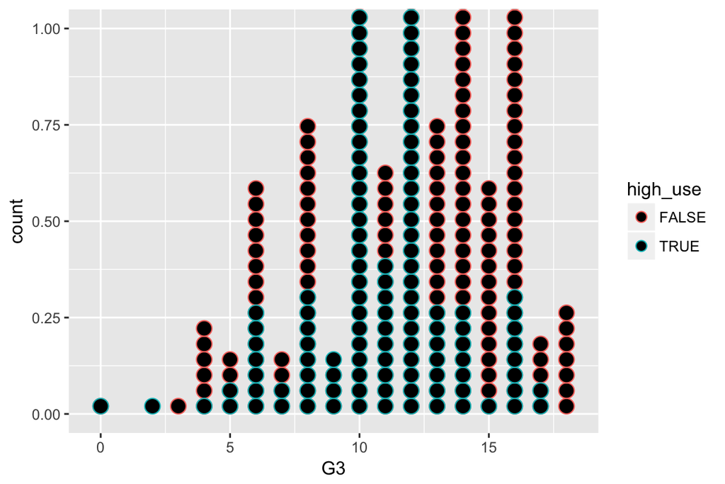

```r
g2 <- ggplot(alc, aes(x = G3, col = high_use))
g2 + geom_dotplot()
```

It seems that FALSE is more common towards the upper end of the grade scale while the TRUEs are concentrated towards the middle. This would support my hypothesis.

## Logistic regression

I now fit a logistic regression model on the dataset, using the `glm` function.

```r
m <- glm(high_use ~ sex + age + Medu + G3, data = alc, family = "binomial")
summary(m)
```

```
##
## Call:
## glm(formula = high_use ~ sex + age + Medu + G3, family = "binomial",
##     data = alc)
##
## Deviance Residuals:
##     Min       1Q   Median       3Q      Max
## -1.5188  -0.8574  -0.6693   1.2185   2.0521
##
## Coefficients:
##             Estimate Std. Error z value Pr(>|z|)
## (Intercept) -3.69109    1.82693  -2.020 0.043344 *
## sexM         0.87831    0.23478   3.741 0.000183 ***
## age          0.18551    0.10004   1.854 0.063691 .
## Medu         0.06228    0.11103   0.561 0.574830
## G3          -0.07838    0.03616  -2.168 0.030171 *
## ---
## Signif. codes:  0 '***' 0.001 '**' 0.01 '*' 0.05 '.' 0.1 ' ' 1
##
## (Dispersion parameter for binomial family taken to be 1)
##
##     Null deviance: 465.68  on 381  degrees of freedom
## Residual deviance: 440.90  on 377  degrees of freedom
## AIC: 450.9
##
## Number of Fisher Scoring iterations: 4
```

I now compute the confidence intervals.

```r
library(dplyr)
OR <- coef(m) %>% exp
CI <- confint(m) %>% exp
cbind(OR, CI)
```

```
##                     OR        2.5 %    97.5 %
## (Intercept) 0.02494492 0.0006625863 0.8709274
## sexM        2.40684013 1.5257844762 3.8361931
## age         1.20383314 0.9907875565 1.4680981
## Medu        1.06426277 0.8572699654 1.3260686
## G3          0.92460997 0.8605396713 0.9919652
```

The confidence intervals confirm the analysis presented above: the intervals for age and the mother’s education include 1.00, which means that they are unreliable predictors. The intervals for sex and grade are on either side of 1.00, which means that they work as predictors.

## Predictions

Lastly, I check how well the model manages to predict the observations.

```r
probabilities <- predict(m, type = "response")
alc <- mutate(alc, probability = probabilities)
alc <- mutate(alc, prediction = alc$probability > 0.5)
table(high_use = alc$high_use, prediction = alc$probability > 0.5)
```

```
##         prediction
## high_use FALSE TRUE
##    FALSE   258   10
##    TRUE    103   11
```

The value ‘FALSE’ is predicted with a high accuracy. By contrast, ‘TRUE’ is quite weakly predicted. Therefore, the model requires a bit more work.

# Chapter 4: Clustering and classification

## Introduction

This week’s exercise is about clustering and classification. The dataset will be `Boston`, one of the datasets that come with installing R. It is located in the `MASS` package.  
First, I load the dataset.

```r
library(MASS)
data("Boston")
```

Then, I have a look at the structure and dimensions of the dataset.

```r
str(Boston)
```

```
## 'data.frame':    506 obs. of  14 variables:
##  $ crim   : num  0.00632 0.02731 0.02729 0.03237 0.06905 ...
##  $ zn     : num  18 0 0 0 0 0 12.5 12.5 12.5 12.5 ...
##  $ indus  : num  2.31 7.07 7.07 2.18 2.18 2.18 7.87 7.87 7.87 7.87 ...
##  $ chas   : int  0 0 0 0 0 0 0 0 0 0 ...
##  $ nox    : num  0.538 0.469 0.469 0.458 0.458 0.458 0.524 0.524 0.524 0.524 ...
##  $ rm     : num  6.58 6.42 7.18 7 7.15 ...
##  $ age    : num  65.2 78.9 61.1 45.8 54.2 58.7 66.6 96.1 100 85.9 ...
##  $ dis    : num  4.09 4.97 4.97 6.06 6.06 ...
##  $ rad    : int  1 2 2 3 3 3 5 5 5 5 ...
##  $ tax    : num  296 242 242 222 222 222 311 311 311 311 ...
##  $ ptratio: num  15.3 17.8 17.8 18.7 18.7 18.7 15.2 15.2 15.2 15.2 ...
##  $ black  : num  397 397 393 395 397 ...
##  $ lstat  : num  4.98 9.14 4.03 2.94 5.33 ...
##  $ medv   : num  24 21.6 34.7 33.4 36.2 28.7 22.9 27.1 16.5 18.9 ...
```

```r
dim(Boston)
```

```
## [1] 506  14
```

There are 506 rows and 14 variables in the dataset. There is more information on the dataset [here](https://stat.ethz.ch/R-manual/R-devel/library/MASS/html/Boston.html). The dataset concerns housing values in various suburbs of Boston. The background variables range from crime statistics to the average number of rooms per dwelling and whether the suburb bounds Charles River or not.